# Holt and Holt-Winters Models – Model Evaluation

15 April 2025

## Exponential Smoothing Models

[ETS Models in Forecasting: Principles and Practice](https://otexts.com/fpp2/expsmooth.html)

**Exponential smoothing models** are a family of forecasting tools that help us make smarter predictions by giving **more weight to recent observations** while not completely ignoring the past.

**Why “exponential”?** The weights assigned to past observations decrease exponentially — meaning the most recent data gets the most attention, and older data fades out gradually.

## Simple Level Model

My prediction for today is an exponentially weighted average of past values.

\[ \hat{y}_{t+1} = \ell_t \]

\[ \ell_t = \alpha y_t + \alpha(1 - \alpha) y_{t-1} + \alpha(1 - \alpha)^2 y_{t-2} + \dots \]

## Simple Trend + Level Model (Holt)

My prediction includes both an exponentially weighted average of past values **and** a trend.

“trend” = tendency to increase or decrease.

\[ \hat{y}_{t+1} = \ell_t + b_t \]

Where:

- \(\ell_t\): exponentially weighted average of past values
- \(b_t\): exponentially weighted average of past trends (\(\ell_{t} - \ell_{t-1}\))

## Expanded Form

**Level:** \[ \ell_t = \alpha y_t + \alpha(1 - \alpha)(y_{t-1} + b_{t-1}) + \alpha(1 - \alpha)^2(y_{t-2} + b_{t-2}) + \dots \]

**Trend:** \[ b_t = \beta (\ell_t - \ell_{t-1}) + \beta (1 - \beta) (\ell_{t-1} - \ell_{t-2}) + (1-\beta)^2 b_{t-2} \]

## Holt-Winters Model

My forecast includes a weighted average of past values, a trend, **and** a seasonal component:

\[ \hat{y}_{t+1} = \ell_t + b_t + s_{t - m} \]

Where: - \(\ell_t\): smoothed level (local average) - \(b_t\): smoothed trend (local slope) - \(s_{t - m}\): seasonal adjustment from one full cycle ago

## Expanded form of seasonality:

\[ \begin{aligned} s_t &= \gamma (y_t - \ell_t) + (1 - \gamma) s_{t - m} \\ &= \gamma (y_t - \ell_t) + \gamma(1 - \gamma)(y_{t - m} - \ell_{t - m}) \\ &\quad + \gamma(1 - \gamma)^2(y_{t - 2m} - \ell_{t - 2m}) + \gamma(1 - \gamma)^3(y_{t - 3m} - \ell_{t - 3m}) + \dots \end{aligned} \]

This lets the **seasonal pattern** evolve gradually over time.

## Fitting Holt and Holt-Winters

The forecast package provides:

- `holt(dat)`, `ets(dat, model="AAN")` Holt
- `hw(dat)`, `ets(dat, model="AAA")` Holt-Winters
- `ets(dat, model="ZZZ")` others

## Fit Holt model

Evolving level and trend.

Load the data and **forecast** package.

```r
data(greeklandings, package="atsalibrary")
anchovy <- subset(greeklandings,
                  Species=="Anchovy" & Year<=1987)$log.metric.tons
anchovy <- ts(anchovy, start=1964)
library(forecast)
fit <- forecast::holt(anchovy)
fr <- forecast(fit, h=5)
```

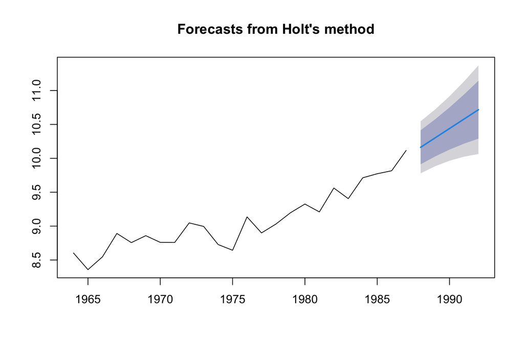

```r
plot(fr)
```

## Validation

Once we have a model(s), we will want to evaluate the performance of the model. We’ll see examples using the anchovy landings.

```r
spp <- "Anchovy"
training = subset(greeklandings, Year <= 1987)
test = subset(greeklandings, Year >= 1988 & Year <= 1989)
traindat <- subset(training, Species==spp)$log.metric.tons
testdat <- subset(test, Species==spp)$log.metric.tons
```

## Measures of forecast fit

To measure the forecast fit, we fit a model to training data and test a forecast against data in a test set. We ‘held out’ the test data and did not use it for fitting.

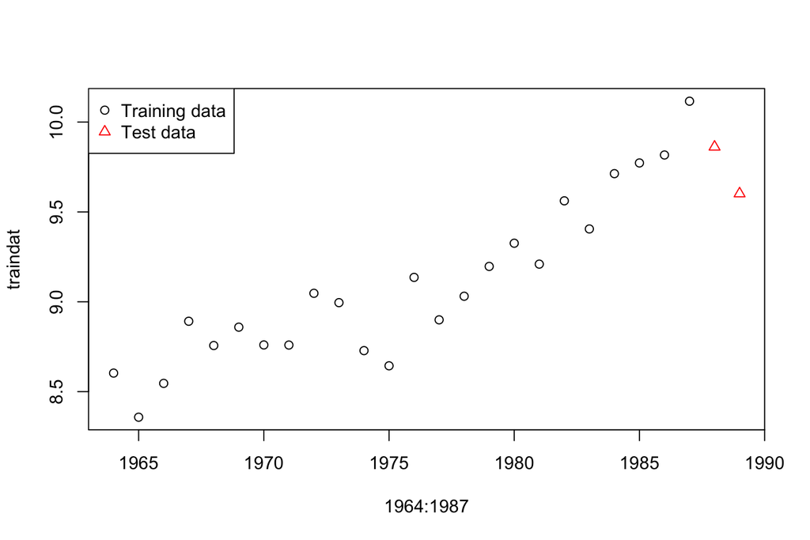

We will fit to the training data and make a forecast.

```r
fit_arima <- auto.arima(traindat)
fit_arima
```

```
## Series: traindat
## ARIMA(0,1,1) with drift
##
## Coefficients:
##           ma1   drift
##       -0.5731  0.0641
## s.e.   0.1610  0.0173
##
## sigma^2 = 0.03583:  log likelihood = 6.5
## AIC=-6.99   AICc=-5.73   BIC=-3.58
```

## Forecast

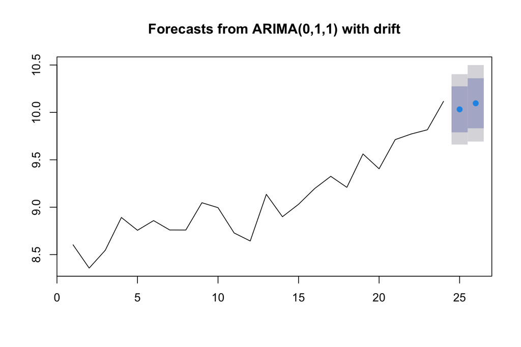

```r
fr <- forecast(fit_arima, h=2)
plot(fr)
```

## Compare to test

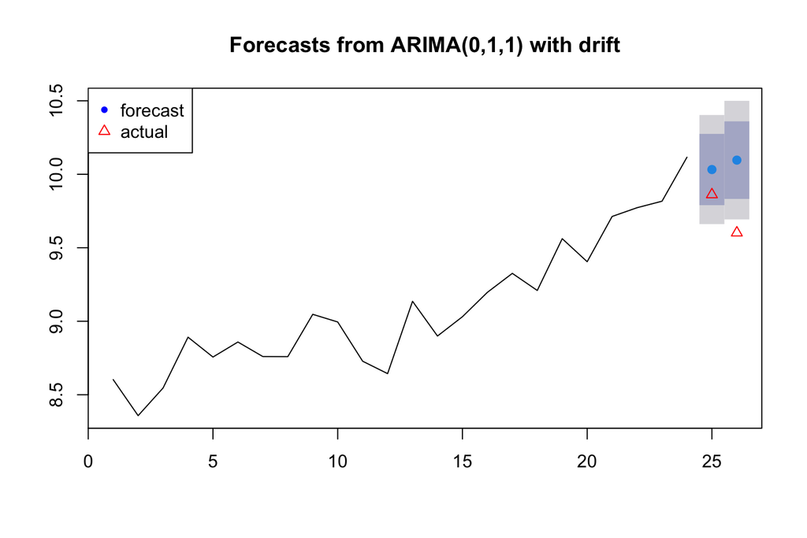

How do we quantify the difference between the forecast and the actual values?

```r
fr.err <- testdat - fr$mean
fr.err
```

```
## Time Series:
## Start = 25
## End = 26
## Frequency = 1
## [1] -0.1704302 -0.4944778
```

There are many metrics. The `accuracy()` function in forecast provides many different metrics: mean error, root mean square error, mean absolute error, mean percentage error, mean absolute percentage error.

### ME Mean error

```r
me <- mean(fr.err); me
```

```
## [1] -0.332454
```

### RMSE Root mean squared error

```r
rmse <- sqrt(mean(fr.err^2)); rmse
```

```
## [1] 0.3698342
```

### MAE Mean absolute error

```r
mae <- mean(abs(fr.err)); mae
```

```
## [1] 0.332454
```

### MPE Mean percentage error

```r
fr.pe <- 100*fr.err/testdat
mpe <- mean(fr.pe); mpe
```

```
## [1] -3.439028
```

### MAPE Mean absolute percentage error

```r
mape <- mean(abs(fr.pe)); mape
```

```
## [1] 3.439028
```

```r
accuracy(fr, testdat)[,1:5]
```

```
##                       ME      RMSE       MAE        MPE     MAPE
## Training set -0.00473511 0.1770653 0.1438523 -0.1102259 1.588409
## Test set     -0.33245398 0.3698342 0.3324540 -3.4390277 3.439028
```

```r
c(me, rmse, mae, mpe, mape)
```

```
## [1] -0.3324540  0.3698342  0.3324540 -3.4390277  3.4390277
```

## Test all the models in your candidate set

Compute metrics for all the models in your candidate set.

```r
# The model picked by auto.arima
fit1 <- Arima(traindat, order=c(0,1,1))
fr1 <- forecast(fit1, h=2)
test1 <- accuracy(fr1, testdat)[2,1:5]

# AR-1
fit2 <- Arima(traindat, order=c(1,1,0))
fr2 <- forecast(fit2, h=2)
test2 <- accuracy(fr2, testdat)[2,1:5]

# Holt
fit3 <- holt(traindat)
fr3 <- forecast(fit3, h=2)
test3 <- accuracy(fr3, testdat)[2,1:5]
```

## Show a summary

|  | ME | RMSE | MAE | MPE | MAPE |
| --- | --- | --- | --- | --- | --- |
| (0,1,1) | -0.293 | 0.320 | 0.293 | -3.024 | 3.024 |
| (1,1,0) | -0.309 | 0.341 | 0.309 | -3.200 | 3.200 |
| Holt | -0.500 | 0.538 | 0.500 | -5.168 | 5.168 |

## Cross-validation

An alternate approach to testing a model’s forecast accuracy is to use windows.

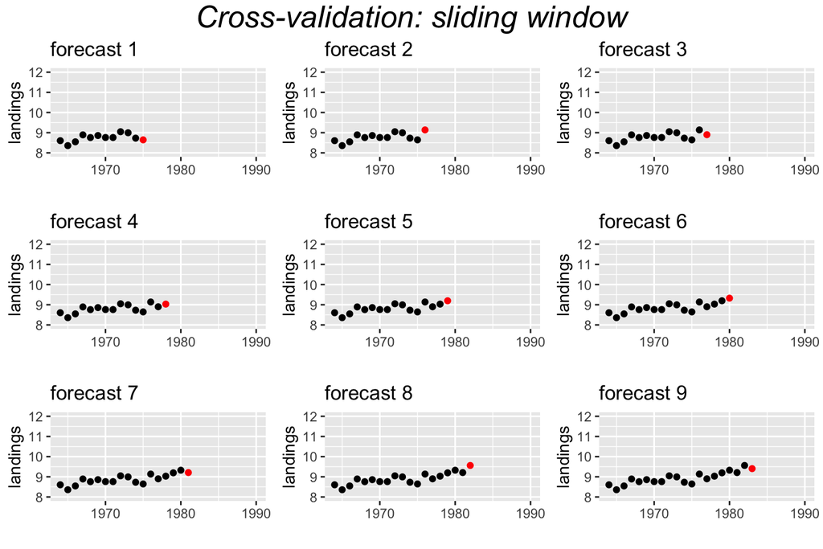

Another approach uses a fixed window. For example, a 10-year window.

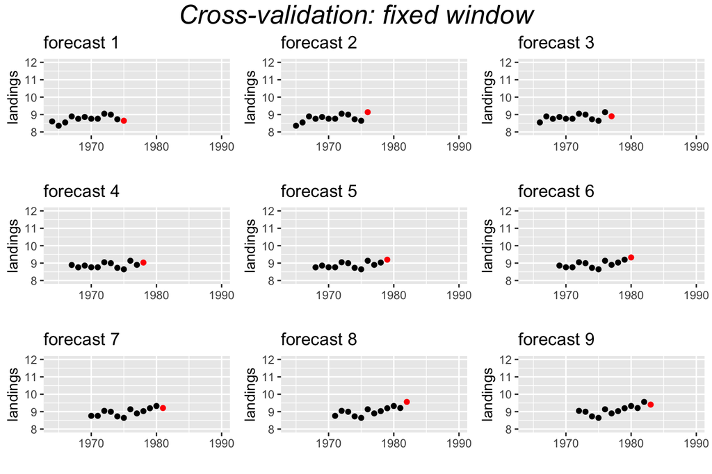

## Time-series cross-validation with the forecast package

```r
far2 <- function(x, h, order){
  forecast(Arima(x, order=order), h=h)
  }
e <- tsCV(traindat, far2, h=1, order=c(0,1,1))
tscv1 <- c(ME=mean(e, na.rm=TRUE), RMSE=sqrt(mean(e^2, na.rm=TRUE)),
           MAE=mean(abs(e), na.rm=TRUE))
tscv1
```

```
##        ME      RMSE       MAE
## 0.1128788 0.2261706 0.1880392
```

Compare to RMSE from just the 2 test data points.

```r
test1[c("ME","RMSE","MAE")]
```

```
##         ME       RMSE        MAE
## -0.2925326  0.3201093  0.2925326
```

## Cross-validation farther in future

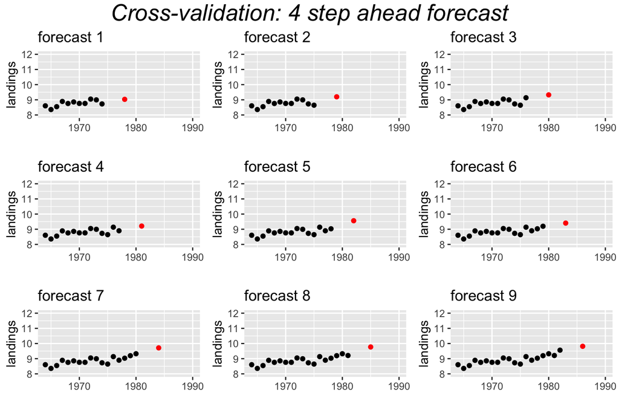

Compare accuracy of forecasts 1 year out versus 4 years out. If `h` is greater than 1, then the errors are returned as a matrix with each `h` in a column. Column 4 is the forecast, 4 years out.

```r
e <- tsCV(traindat, far2, h=4, order=c(0,1,1))[,4]
#RMSE
tscv4 <- c(ME=mean(e, na.rm=TRUE), RMSE=sqrt(mean(e^2, na.rm=TRUE)),
           MAE=mean(abs(e), na.rm=TRUE))
rbind(tscv1, tscv4)
```

```
##              ME      RMSE       MAE
## tscv1 0.1128788 0.2261706 0.1880392
## tscv4 0.2839064 0.3812815 0.3359689
```

Compare accuracy of forecasts with a fixed 10-year window and 1-year out forecasts.

```r
e <- tsCV(traindat, far2, h=1, order=c(0,1,1), window=10)
#RMSE
tscvf1 <- c(ME=mean(e, na.rm=TRUE), RMSE=sqrt(mean(e^2, na.rm=TRUE)),
            MAE=mean(abs(e), na.rm=TRUE))
tscvf1
```

```
##        ME      RMSE       MAE
## 0.1387670 0.2286572 0.1942840
```

```r
comp.tab <- rbind(test1=test1[c("ME","RMSE","MAE")],
      slide1=tscv1,
      slide4=tscv4,
      fixed1=tscvf1)
knitr::kable(comp.tab, format="html")
```

|  | ME | RMSE | MAE |
| --- | --- | --- | --- |
| test1 | -0.2925326 | 0.3201093 | 0.2925326 |
| slide1 | 0.1128788 | 0.2261706 | 0.1880392 |
| slide4 | 0.2839064 | 0.3812815 | 0.3359689 |
| fixed1 | 0.1387670 | 0.2286572 | 0.1942840 |

## Summary forecast performance

We can evaluate the forecast performance with forecasts of our test data or we can use all the data and use time-series cross-validation.

Let’s start with the former.

## Test forecast performance against a test data set

We will fit Holt model to the training data and make a forecast for the years that we ‘held out’.

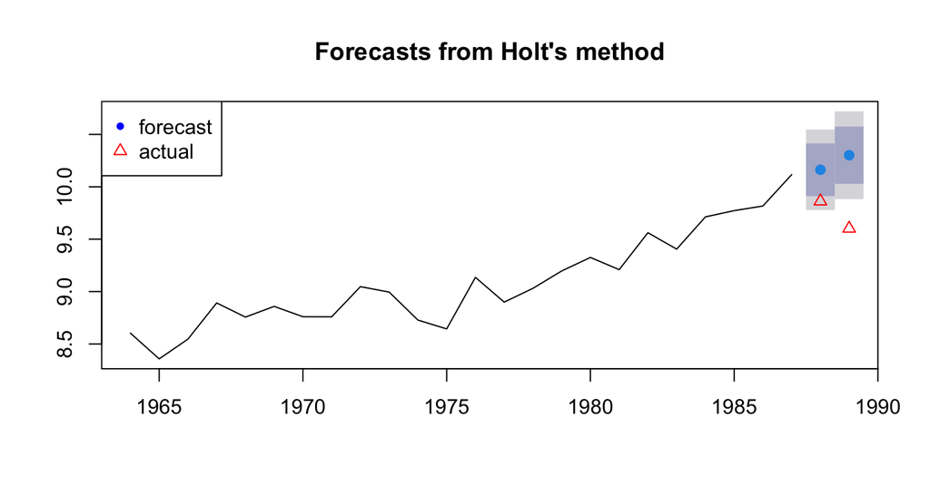

We can calculate a variety of forecast error metrics with

```r
accuracy(fr, testdat)
```

```
##                      ME      RMSE       MAE        MPE     MAPE      MASE
## Training set  0.0155550 0.1788989 0.1442749  0.1272736 1.600569 0.7721001
## Test set     -0.5001404 0.5384071 0.5001404 -5.1675444 5.167544 2.6765467
##                      ACF1 Theil's U
## Training set -0.008467932        NA
## Test set     -0.500000000  2.690789
```

We would now repeat this for all the models in our candidate set and choose the model with the best forecast performance.

## Forecast performance with time-series cross-validation

We can use `tsCV()` as we did for ARIMA models. We will redefine `traindat` as all our Anchovy data.

## tsCV() function

We will use the `tsCV()` function. We need to define a function that returns a forecast.

```r
far2 <- function(x, h){
  fit <- holt(x)
  forecast(fit, h=h)
  }
```

Now we can use `tsCV()` to run our `far2()` function to a series of training data sets. We will specify that a NEW ets model be estimated for each training set. We are not using the weighting estimated for the whole data set but estimating the weighting new for each set.

The `e` are our forecast errors for all the forecasts that we did with the data.

```r
e <- tsCV(traindat, far2, h=1)
c(ME=mean(e, na.rm=TRUE), RMSE=sqrt(mean(e^2, na.rm=TRUE)),
           MAE=mean(abs(e), na.rm=TRUE))
```

```
##         ME       RMSE        MAE
## 0.03393316 0.26161402 0.22468116
```

## Seasonal Holt-Winters

```r
data("chinook", package="atsalibrary")
head(chinook.month)
```

| Year | Month | Species | State | log.metric.tons | metric.tons | value.usd |
| --- | --- | --- | --- | --- | --- | --- |
| 1990 | Jan | Chinook | WA | 3.26 | 26.1 | 108685 |
| 1990 | Feb | Chinook | WA | 3.78 | 43.7 | 309196 |
| 1990 | Mar | Chinook | WA | 3.47 | 32.1 | 201279 |
| 1990 | Apr | Chinook | WA | 4.23 | 69 | 433238 |
| 1990 | May | Chinook | WA | 5.09 | 162 | 876329 |
| 1990 | Jun | Chinook | WA | 4.28 | 71.9 | 421885 |

The data are monthly and start in January 1990. To make this into a ts object do

```r
df <- chinook.month %>% subset(State == "WA")
chinookts <- ts(df$log.metric.tons, start=c(1990,1), frequency=12)
```

`start` is the year and month and frequency is the number of months in the year.

## Plot seasonal data

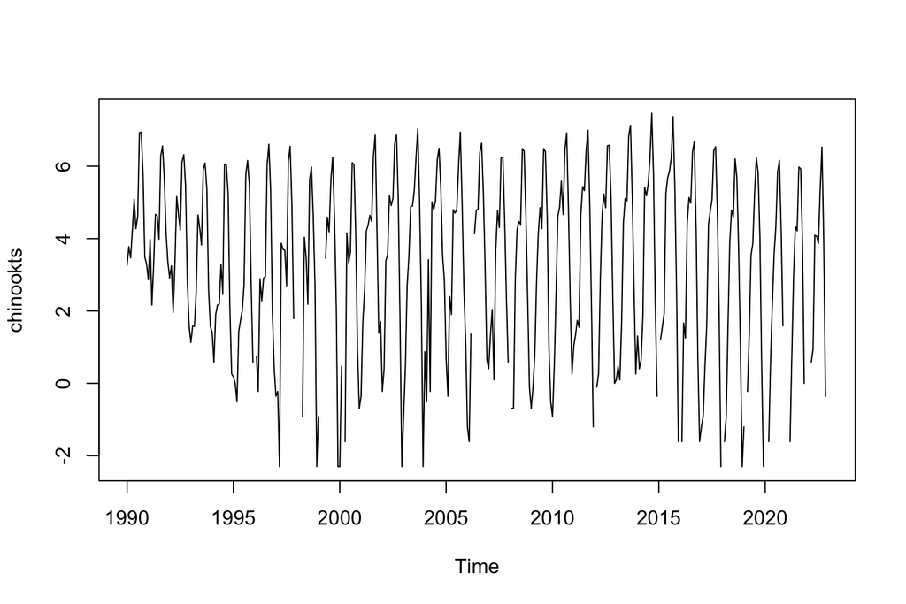

```r
plot(chinookts)
```

## Holt-Winters

```r
library(forecast)
traindat <- window(chinookts, c(1990,1), c(1999,12))
fit <- forecast::hw(traindat)
```

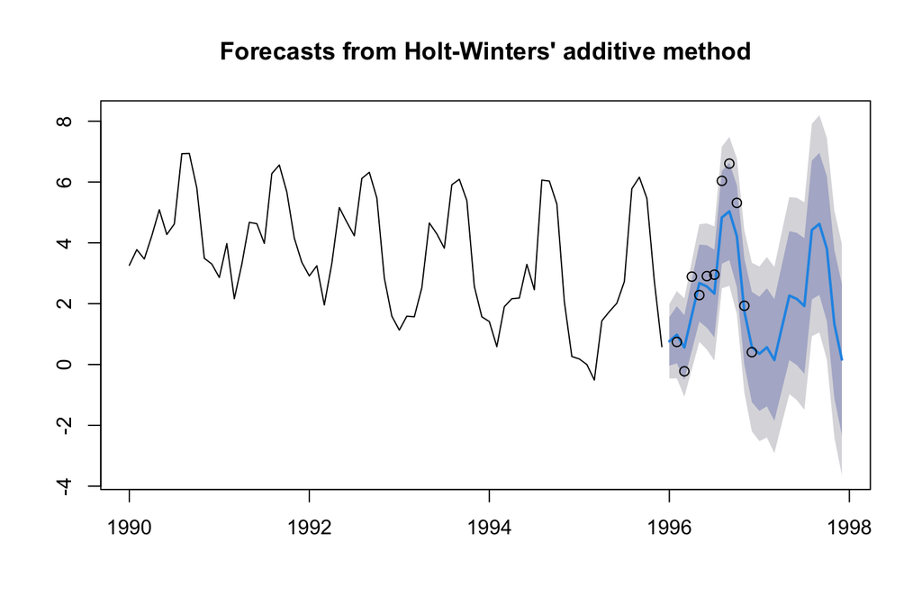

```r
fr <- forecast(fit, h=24)
plot(fr)
points(window(chinookts, c(1996,1), c(1996,12)))
```

## Compare to a seasonal ARIMA model

`auto.arima()` will recognize that our data has season and fit a seasonal ARIMA model to our data. Let’s use the data that `ets()` used. This is shorter than our training data. The data used by `hw()` is returned in `fit$x`.

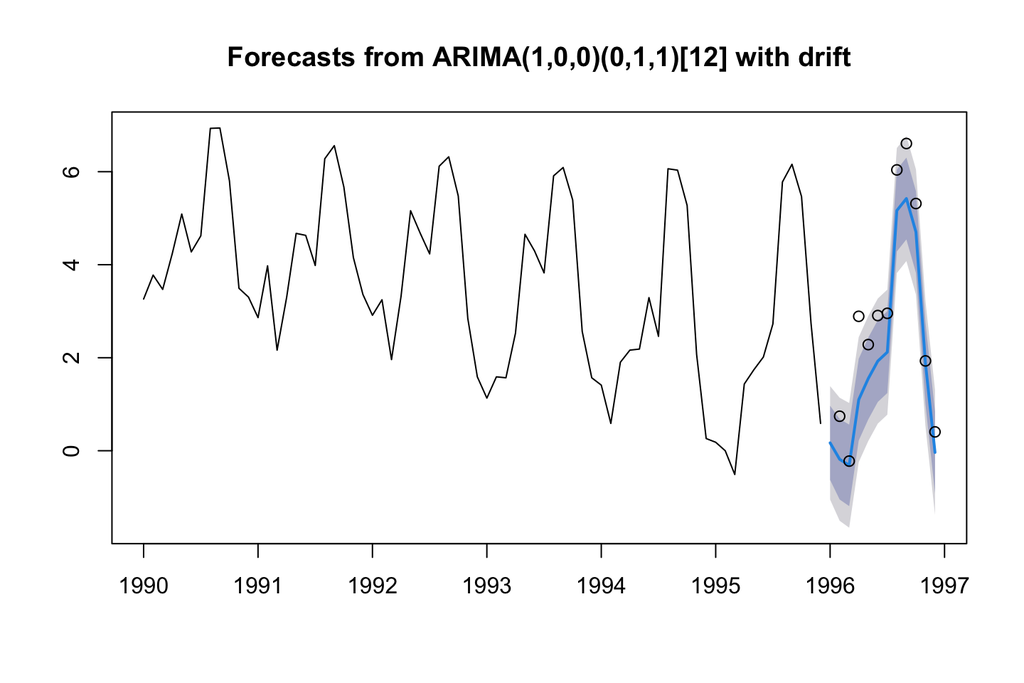

```r
no_miss_dat <- fit$x
fit <- auto.arima(no_miss_dat)
fr <- forecast(fit, h=12)
plot(fr)
points(window(chinookts, c(1996,1), c(1996,12)))
```

## Missing values

Missing values are ok when fitting a seasonal ARIMA model, unlike an ETS model.

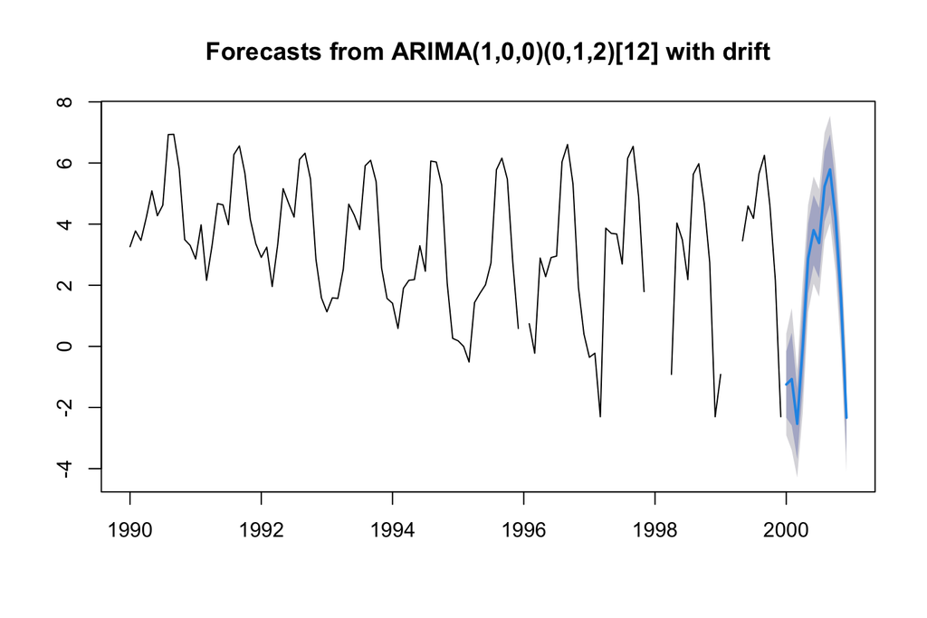

```r
fit <- auto.arima(traindat)
fr <- forecast(fit, h=12)
plot(fr)
```

## Forecast evaluation

We can compute the forecast performance metrics as usual.

```r
fit <- hw(traindat)
fr <- forecast(fit, h=12)
```

Look at the forecast so you know what years and months to include in your test data. Pull those 12 months out of your data using the `window()` function.

```r
testdat <- window(traindat, c(1996,1), c(1996,12))
```

Use `accuracy()` to get the forecast error metrics.

```r
accuracy(fr, testdat)
```

```
##                        ME      RMSE       MAE      MPE    MAPE      MASE
## Training set 0.0009781278 0.5506796 0.4238807     -Inf     Inf 0.7095807
## Test set     0.4269572812 0.8579622 0.7150331 37.32735 53.8648 1.1969730
##                    ACF1 Theil's U
## Training set 0.04312778        NA
## Test set     0.15488159 0.4105402
```

We can do the same for the ARIMA model.

```r
no_miss_dat <- fit$x
fit <- auto.arima(no_miss_dat)
fr <- forecast(fit, h=12)
accuracy(fr, testdat)
```

```
##                       ME      RMSE       MAE     MPE     MAPE      MASE
## Training set 0.008756236 0.5535951 0.3948974    -Inf      Inf 0.6610624
## Test set     0.774509391 0.9045662 0.7745094 35.9946 43.38318 1.2965369
##                     ACF1 Theil's U
## Training set -0.03293199        NA
## Test set     -0.21056349 0.5722577
```